# Pobieranie PWE i EWD na poziomie szkół

Tymoteusz Wołodźko t.wolodzko@ibe.edu.pl

# Wstęp

Poniżej zapoznamy się z:

1. wyszukiwaniem pożądanych wskaźników w grupie danych [wskaźniki](http://zpd.ibe.edu.pl/doku.php?id=r_gr_wskazniki)
2. pobieraniem wartości pożądanych wskaźników z grupy danych [wartości wskaźnków](http://zpd.ibe.edu.pl/doku.php?id=r_gr_wartosciwskaznikow)
3. dołączaniem do wartości wskaźników informacji o szkołach i odfiltrowywanie pobieranych danych do wybranego zakresu, np. po typie szkoły, województwie, itp. (grupa danych [szkoły](http://zpd.ibe.edu.pl/doku.php?id=r_gr_szkoly))

## Przydatne linki:

- [podsumowanie informacji o grupach danych](http://zpd.ibe.edu.pl/doku.php?id=r_gr#podsumowanie_informacji_o_grupach_danych)
- [indeks zmiennych w grupach danych](http://zpd.ibe.edu.pl/doku.php?id=r_zmienne)

## Funkcje, z których będziemy korzystać:

- `pobierz_wskazniki()`
- `pobierz_wartosci_wskaznikow()`
- `pobierz_szkoly()`

## Czynności wstępne

Zacznijmy od załadowania pakietu ZPD i połączenia się z bazą danych: ]

```r
# devtools::install_github('zozlak/ZPD')

# importujemy pakiet ZPD i nawiązujemy połączenie z bazą danych IBE
library(ZPD)
src = polacz()

# do tworzenia wykresów przyda nam się biblioteka ggplot2
# więcej informacji na jego temat można znaleźć na stronie: http://www.cookbook-r.com
library(ggplot2)
```

# Wyszukiwanie wskaźników EWD/PWE

Punktem wyjścia do pobrania wskaźników EWD/PWE dla szkół jest ustalenie, jaki dokładnie wskaźnik chcemy pobrać, występują one bowiem w wielu odmianach ze względu na rodzaj egzaminu (sprawdzian/egzamin gimnazjalny/matura), część egzaminu, typ szkoły, itp.

W tym celu przeanalizujemy zawartość zbioru danych [wskaźniki](http://zpd.ibe.edu.pl/doku.php?id=r_gr_wskazniki)

Na początek pobierzemy cały zbiór danych *wskazniki*.  
O ile nie jest to zalecane w przypadku większości zasobów bazy, w tym wypadku jest on na tyle mały, że nie będzie to stanowić problemu.

```r
wskazniki_all = pobierz_wskazniki(src) %>%
  collect()
```

Podejrzyjmy teraz pierwsze kilka wierszy pobranego zbioru:

```r
wskazniki_all
```

```
## Source: local data frame [210 x 12]
##
##    rodzaj_wsk wskaznik okres wsk_do_prezentacji              skrot
## 1         pwe  paou_gh     1               TRUE gim. humanistyczny
## 2         pwe  paou_gh     1               TRUE gim. humanistyczny
## 3         pwe  paou_gh     1               TRUE gim. humanistyczny
## 4         pwe  paou_gh     1               TRUE gim. humanistyczny
## 5         pwe  paou_gh     1               TRUE gim. humanistyczny
## 6         pwe  paou_gh     1               TRUE gim. humanistyczny
## 7         pwe  paou_gh     1               TRUE gim. humanistyczny
## 8         pwe  paou_gh     1               TRUE gim. humanistyczny
## 9         pwe  paou_gh     1               TRUE gim. humanistyczny
## 10        pwe  paou_gh     1               TRUE gim. humanistyczny
## ..        ...      ...   ...                ...                ...
## Variables not shown: opis_wsk (chr), rok_do (int), typ_szkoly (chr),
##   rodzaj_egzaminu (chr), czesc_egzaminu (chr), id_skali (int), skalowanie
##   (int)
```

Jak widzimy, ma on 210 obserwacji i 12 zmiennych.  
Opis poszczególnych zmiennych znajdziemy na [tej stronie](http://zpd.ibe.edu.pl/doku.php?id=r_zmienne&zm=wskazniki).  
Zmienne te będą nam służyć do późniejszego filtrowania wyników znajdujących się w bazie danych.

Sprawdźmy jakie wartości przyjmują wybrane zmienne:

```r
unique(wskazniki_all$rodzaj_wsk)
```

```
## [1] "pwe" "ewd"
```

```r
unique(wskazniki_all$rodzaj_egzaminu)
```

```
## [1] "egzamin gimnazjalny" "sprawdzian"          "matura"
```

```r
unique(wskazniki_all$typ_szkoly)
```

```
## [1] "gimn." "SP"    "LO"    "T"
```

```r
unique(wskazniki_all$czesc_egzaminu)
```

```
##  [1] "humanistyczna"             "matematyczno-przyrodnicza"
##  [3] ""                          "j. polski"
##  [5] "historia i WOS"            "matematyka"
##  [7] "przedmioty przyrodnicze"   NA
##  [9] "j. polski podstawowa"      "historia podstawowa"
## [11] "WOS podstawowa"            "matematyka podstawowa"
## [13] "biologia podstawowa"       "chemia podstawowa"
## [15] "fizyka podstawowa"         "geografia podstawowa"
## [17] "informatyka podstawowa"    "j. polski rozszerzona"
## [19] "historia rozszerzona"      "WOS rozszerzona"
## [21] "matematyka rozszerzona"    "biologia rozszerzona"
## [23] "chemia rozszerzona"        "fizyka rozszerzona"
## [25] "geografia rozszerzona"     "informatyka rozszerzona"
```

```r
unique(wskazniki_all$okres) # okres == 1 dla PWE i okres == 2 lub 3 dla EWD
```

```
## [1] 1 3
```

Zmienna *wskaznik* w zbiorze danych *wskazniki* to identyfikator oszacowania PWE lub EWD, którego opis znajdziemy w zmiennej *opis_wsk*:

```r
unique(wskazniki_all$wskaznik)
```

```
##  [1] "paou_gh"     "paou_gmp"    "paou_sp"     "gh_bt_mod"   "gh_p_bt_mod"
##  [6] "gh_h_bt_mod" "gmp_bt_mod"  "gm_m_bt_mod" "gm_p_bt_mod" "mlp_tl_wgr"
## [11] "mth_tl_wgr"  "mtp_tl_wgr"  "mtm_tl_wgr"  "mlh_tl_wgr"  "mtmp_tl_wgr"
## [16] "mlmp_tl_wgr" "mlm_tl_wgr"
```

Korzystając z opisanych powyżej zmiennych możemy odpowiednio filtrować ramkę danych w poszukiwaniu interesującego nas wskaźnika.  
W tym celu przydatne będą funkcje `filter()`, `select()` oraz `arrange()` omawiane na wcześniejszym warsztacie.  
Dodatkowo, możemy skorzystać z funkcji `distinct()`, która usuwa ze zbioru danych duplikaty.

Spróbujmy zatem wyszukać wybrane wskaźniki PWE/EWD:

1. Wskaźniki PWE dla sprawdzianu (takie jak w serwisie internetowym):

```r
wskazniki_all %>%
  filter(
    rodzaj_wsk == "pwe",
    rodzaj_egzaminu == "sprawdzian"
  ) %>%
  arrange(rok_do, skrot) %>%
  select(rodzaj_wsk, wskaznik, okres, wsk_do_prezentacji, skrot, rok_do, typ_szkoly, rodzaj_egzaminu, czesc_egzaminu)
```

```
## Source: local data frame [12 x 9]
##
##    rodzaj_wsk wskaznik okres wsk_do_prezentacji                     skrot
## 1         pwe  paou_sp     1               TRUE sprawdzian szóstoklasisty
## 2         pwe  paou_sp     1               TRUE sprawdzian szóstoklasisty
## 3         pwe  paou_sp     1               TRUE sprawdzian szóstoklasisty
## 4         pwe  paou_sp     1               TRUE sprawdzian szóstoklasisty
## 5         pwe  paou_sp     1               TRUE sprawdzian szóstoklasisty
## 6         pwe  paou_sp     1               TRUE sprawdzian szóstoklasisty
## 7         pwe  paou_sp     1               TRUE sprawdzian szóstoklasisty
## 8         pwe  paou_sp     1               TRUE sprawdzian szóstoklasisty
## 9         pwe  paou_sp     1               TRUE sprawdzian szóstoklasisty
## 10        pwe  paou_sp     1               TRUE sprawdzian szóstoklasisty
## 11        pwe  paou_sp     1               TRUE sprawdzian szóstoklasisty
## 12        pwe  paou_sp     1               TRUE sprawdzian szóstoklasisty
## Variables not shown: rok_do (int), typ_szkoly (chr), rodzaj_egzaminu
##   (chr), czesc_egzaminu (chr)
```

Jak widać w tym wypadku mamy do czynienia z jednym wskaźnikiem (zmienna *wskaznik*) **paou_sp**, który występuje dla lat 2002-2013.

2. Wskaźniki EWD dla matury z języka polskiego:

```r
wskazniki_all %>%
  filter(
    rodzaj_wsk == "ewd",
    wsk_do_prezentacji == TRUE,
    rodzaj_egzaminu == "matura",
    czesc_egzaminu %in% c("j. polski podstawowa", "j. polski rozszerzona")
  ) %>%
  arrange(rok_do, skrot) %>%
  select(rodzaj_wsk, wskaznik, okres, wsk_do_prezentacji, skrot, rok_do, typ_szkoly, rodzaj_egzaminu, czesc_egzaminu)
```

```
## Source: local data frame [24 x 9]
##
##    rodzaj_wsk   wskaznik okres wsk_do_prezentacji         skrot rok_do
## 1         ewd mlh_tl_wgr     3               TRUE humanistyczny   2012
## 2         ewd mth_tl_wgr     3               TRUE humanistyczny   2012
## 3         ewd mlh_tl_wgr     3               TRUE humanistyczny   2012
## 4         ewd mth_tl_wgr     3               TRUE humanistyczny   2012
## 5         ewd mlp_tl_wgr     3               TRUE  język polski   2012
## 6         ewd mtp_tl_wgr     3               TRUE  język polski   2012
## 7         ewd mlp_tl_wgr     3               TRUE  język polski   2012
## 8         ewd mtp_tl_wgr     3               TRUE  język polski   2012
## 9         ewd mlh_tl_wgr     3               TRUE humanistyczny   2013
## 10        ewd mth_tl_wgr     3               TRUE humanistyczny   2013
## ..        ...        ...   ...                ...           ...    ...
## Variables not shown: typ_szkoly (chr), rodzaj_egzaminu (chr),
##   czesc_egzaminu (chr)
```

W tym wypadku mamy do czynienia z 4 różnymi wskaźnikami (zmienna *wskaznik*):

- **mlh_tl_wgr** (wskaźnik humanistyczny dla LO),
- **mth_tl_wgr** (wskaźnik humanistyczny dla techników),
- **mlp_tl_wgr** (wskaźnik dla j. polskiego dla LO),
- **mtp_tl_wgr** (wskaźnik dla j. polskiego dla T).

Przy czym każdy z nich występuje dla 3 okresów: 2010-2012, 2011-2013, 2012-2014 (patrz kombinacje zmiennych *rok_do* oraz *okres*).

Umiejąc znaleźć interesujące nas wskaźniki, możemy przejść do pobierania ich wartości.

# Pobieranie wartości wskaźników EWD/PWE

Znając identyfikator wskaźnika, który chcemy pobrać (wartość zmiennej *wskaznik* w grupie danych [wskaźniki](http://zpd.ibe.edu.pl/doku.php?id=r_gr_wskazniki)), możemy pobrać z bazy jego wartości.

Znajdują się one w grupie danych [wartości wskaźnków](http://zpd.ibe.edu.pl/doku.php?id=r_gr_wartosciwskaznikow), a do ich pobrania służy funkcja `pobierz_wartosci_wskaznikow()`.

Pobierzmy np. wartości wskaźnika **paou_sp** (PWE dla sprawdzianu):

```r
pwe_spr = pobierz_wartosci_wskaznikow(src) %>%
  filter(wskaznik == 'paou_sp')
pwe_spr
```

```
## Source: postgres 9.4.1 [ewd_baza@ewd.ibe.edu.pl:5432/ewd]
## From: <derived table> [?? x 31]
## Filter: wskaznik == "paou_sp"
##
##    id_ww rodzaj_wsk wskaznik okres_wsk rok_do id_szkoly  rok
## 1  42055        pwe  paou_sp      2002   2002     40418 2002
## 2  42056        pwe  paou_sp      2002   2002     40419 2002
## 3  42057        pwe  paou_sp      2002   2002     40420 2002
## 4  42058        pwe  paou_sp      2002   2002     40421 2002
## 5  42059        pwe  paou_sp      2002   2002     40423 2002
## 6  42060        pwe  paou_sp      2002   2002     40424 2002
## 7  42061        pwe  paou_sp      2002   2002     40425 2002
## 8  42062        pwe  paou_sp      2002   2002     40426 2002
## 9  42063        pwe  paou_sp      2002   2002     40432 2002
## 10 42064        pwe  paou_sp      2002   2002     40433 2002
## ..   ...        ...      ...       ...    ...       ...  ...
## Variables not shown: poziom_agregacji (chr), teryt_jst (int), gmina_jst
##   (chr), powiat_jst (chr), wojewodztwo_jst (chr), pomin (lgl), kategoria
##   (int), wyswietlaj (lgl), komunikat (chr), srednia (dbl), bs (dbl), q1
##   (dbl), mediana (dbl), q3 (dbl), min (dbl), max (dbl), ewd (dbl), bs_ewd
##   (dbl), trend_ewd (dbl), bs_trend_ewd (dbl), korelacja (dbl), lu (int),
##   lu_ewd (int), lu_wszyscy (int)
```

Zamiast podawać nazwę wskaźnika ręcznie, możemy dokonać odfiltrowania za pomocą funkcji `semi_join()` i odfiltrowanej wcześniej grupy danych [wskaźniki](http://zpd.ibe.edu.pl/doku.php?id=r_gr_wskazniki):

```r
# wyszukujemy wskaźnik PWE dla sprawdzianu
wskaznik_spr = pobierz_wskazniki(src) %>%
  filter(
    rodzaj_wsk == "pwe",
    rodzaj_egzaminu == "sprawdzian"
  )
wskaznik_spr %>% select(wskaznik) %>% distinct() # podglądamy nazwę wskaźnika
```

```
## Source: postgres 9.4.1 [ewd_baza@ewd.ibe.edu.pl:5432/ewd]
## From: <derived table> [?? x 1]
##
##    wskaznik
## 1   paou_sp
## ..      ...
```

```r
pwe_spr = pobierz_wartosci_wskaznikow(src) %>%
  semi_join(wskaznik_spr)
pwe_spr
```

```
## Source: postgres 9.4.1 [ewd_baza@ewd.ibe.edu.pl:5432/ewd]
## From: <derived table> [?? x 31]
##
##     id_ww rodzaj_wsk wskaznik okres_wsk rok_do id_szkoly  rok
## 1  283164        pwe  paou_sp      2003   2003     45950 2003
## 2  283170        pwe  paou_sp      2003   2003     45739 2003
## 3  908034        pwe  paou_sp      2003   2003     31679 2003
## 4  908035        pwe  paou_sp      2003   2003     31680 2003
## 5  908036        pwe  paou_sp      2003   2003     31681 2003
## 6  908037        pwe  paou_sp      2003   2003     31682 2003
## 7  908038        pwe  paou_sp      2003   2003     31683 2003
## 8  908039        pwe  paou_sp      2003   2003     31684 2003
## 9  908040        pwe  paou_sp      2003   2003     31685 2003
## 10 908041        pwe  paou_sp      2003   2003     31686 2003
## ..    ...        ...      ...       ...    ...       ...  ...
## Variables not shown: poziom_agregacji (chr), teryt_jst (int), gmina_jst
##   (chr), powiat_jst (chr), wojewodztwo_jst (chr), pomin (lgl), kategoria
##   (int), wyswietlaj (lgl), komunikat (chr), srednia (dbl), bs (dbl), q1
##   (dbl), mediana (dbl), q3 (dbl), min (dbl), max (dbl), ewd (dbl), bs_ewd
##   (dbl), trend_ewd (dbl), bs_trend_ewd (dbl), korelacja (dbl), lu (int),
##   lu_ewd (int), lu_wszyscy (int)
```

Spróbujmy teraz zwizualizować wyniki dla województw w sposób analogiczny do tego, jak w serwisie internetowym PWE: (95% przedziały ufności własności średniej, co odpowiada +/- 1,96 * błąd standardowy)

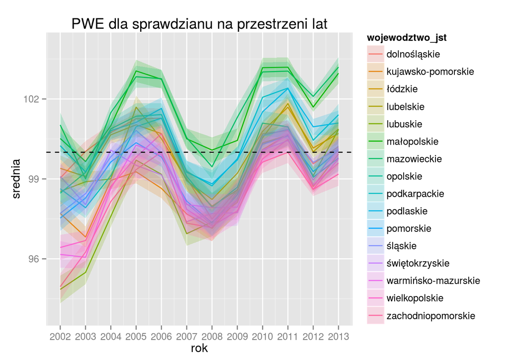

```r
# odfiltrowujemy dane województw
# i ograniczamy się do zmiennych: rok, województwo, srednia i bs
pwe_spr_woj = pwe_spr %>%
  filter(poziom_agregacji == "województwo") %>%
  select(rok, wojewodztwo_jst, srednia, bs) %>%
  collect()

ggplot(pwe_spr_woj, aes(x = rok, y = srednia, color = wojewodztwo_jst, fill = wojewodztwo_jst)) +
  geom_line(size=.5) +
  geom_ribbon(aes(ymin = srednia - 1.96 * bs, ymax = srednia + 1.96 * bs), alpha = 0.2, colour = NA) +
  scale_x_continuous(breaks = 2002:2013) +
  ggtitle("PWE dla sprawdzianu na przestrzeni lat") +
  ylim(94, 104) +
  geom_hline(aes(yintercept = 100), linetype = "dashed")
```

Podobnie możemy pobrać np. wskaźniki PWE dla części humanistycznej egzaminu gimnazjalnego dla powiatów z województwa pomorskiego:

```r
# wyszukujemy wskaźnik PWE dla części humanistycznej egzaminu gimnazjalnego
wskaznik_gh = pobierz_wskazniki(src) %>%
  filter(
    rodzaj_wsk == "pwe",
    rodzaj_egzaminu == "egzamin gimnazjalny",
    czesc_egzaminu == "humanistyczna"
  )
wskaznik_gh %>% select(wskaznik) %>% distinct() # podglądamy nazwę wskaźnika
```

```
## Source: postgres 9.4.1 [ewd_baza@ewd.ibe.edu.pl:5432/ewd]
## From: <derived table> [?? x 1]
##
##    wskaznik
## 1   paou_gh
## ..      ...
```

```r
# pobieramy wartości wskaźnika odfiltrowując tylko powiaty w woj. pomorskim
# (wskaźnik odfiltrowujemy złączając z pobraną przed chwilą nazwą wskaźnika)
pwe_gh_pomorskie = pobierz_wartosci_wskaznikow(src) %>%
  semi_join(wskaznik_gh) %>%
  filter(
    wojewodztwo_jst == 'pomorskie',
    poziom_agregacji == 'powiat'
  ) %>%
  collect()
pwe_gh_pomorskie
```

```
## Source: local data frame [240 x 31]
##
##     id_ww rodzaj_wsk wskaznik okres_wsk rok_do id_szkoly  rok
## 1  442248        pwe  paou_gh      2007   2007        NA 2007
## 2  442249        pwe  paou_gh      2007   2007        NA 2007
## 3  442250        pwe  paou_gh      2007   2007        NA 2007
## 4  442251        pwe  paou_gh      2007   2007        NA 2007
## 5  442252        pwe  paou_gh      2007   2007        NA 2007
## 6  442253        pwe  paou_gh      2007   2007        NA 2007
## 7  442254        pwe  paou_gh      2007   2007        NA 2007
## 8  442255        pwe  paou_gh      2007   2007        NA 2007
## 9  442256        pwe  paou_gh      2007   2007        NA 2007
## 10 442257        pwe  paou_gh      2007   2007        NA 2007
## ..    ...        ...      ...       ...    ...       ...  ...
## Variables not shown: poziom_agregacji (chr), teryt_jst (int), gmina_jst
##   (chr), powiat_jst (chr), wojewodztwo_jst (chr), pomin (lgl), kategoria
##   (int), wyswietlaj (lgl), komunikat (chr), srednia (dbl), bs (dbl), q1
##   (dbl), mediana (dbl), q3 (dbl), min (dbl), max (dbl), ewd (dbl), bs_ewd
##   (dbl), trend_ewd (dbl), bs_trend_ewd (dbl), korelacja (dbl), lu (int),
##   lu_ewd (int), lu_wszyscy (int)
```

Teraz możemy jeszcze np. odfiltrować jedynie wyniki dla 2007 roku i posortować je od najwyższych do najniższych w województwie (na podstawie wartości średniej).

```r
pwe_gh_pomorskie %>%
  filter(rok == 2007) %>%
  select(rok, powiat_jst, srednia, bs, lu) %>%
  arrange(desc(srednia))
```

```
## Source: local data frame [20 x 5]
##
##     rok   powiat_jst  srednia       bs   lu
## 1  2007       Gdynia 101.0540 0.352323 2689
## 2  2007       Gdańsk  97.8704 0.271136 4961
## 3  2007        Sopot  97.1799 0.960253  335
## 4  2007       Słupsk  97.1272 0.519144 1235
## 5  2007     lęborski  94.5375 0.566557  990
## 6  2007      gdański  93.8605 0.497029 1285
## 7  2007   kwidzyński  93.5749 0.520718 1144
## 8  2007   kościerski  93.3903 0.545803 1073
## 9  2007  wejherowski  93.2897 0.342716 2945
## 10 2007     tczewski  93.2880 0.455804 1599
## 11 2007    chojnicki  92.3868 0.466618 1485
## 12 2007     kartuski  92.1934 0.414877 1831
## 13 2007 starogardzki  92.0524 0.427717 1939
## 14 2007    malborski  91.9520 0.561589  981
## 15 2007     bytowski  91.9325 0.507582 1274
## 16 2007  człuchowski  91.3369 0.574281  905
## 17 2007        pucki  91.1436 0.541720 1037
## 18 2007     sztumski  91.0093 0.742215  583
## 19 2007  nowodworski  90.5128 0.767443  529
## 20 2007      słupski  87.8202 0.507607 1368
```

### Pobieranie wartości wskaźników dla szkół

Oczywiście jest również możliwe pobranie wartości wskaźników EWD/PWE dla szkół.

Ponieważ jednak grupa danych [wartości wskaźnków](http://zpd.ibe.edu.pl/doku.php?id=r_gr_wartosciwskaznikow) zawiera jedynie identyfikator szkoły w bazie IBE (zmienna *id_szkoly*), aby móc zidentyfikować szkołę niezbędne będzie pobranie i dołączenie danych z grupy danych [szkoły](http://zpd.ibe.edu.pl/doku.php?id=r_gr_szkoly). Do pobrania grupy danych *szkoły* służy funkcja `pobierz_szkoly()`.

Pobierzmy np. wartości wszystkich wskaźników PWE dla wszystkich gimnazjów w województwie opolskim dla roku 2010.  
Zauważmy, że w tym wypadku:

- Województwo, w którym leżą szkoły musimy odfiltrować w ramach grupy danych [szkoły](http://zpd.ibe.edu.pl/doku.php?id=r_gr_szkoly), bo właśnie tam znajduje się ta informacja.
- Rok możemy odfiltrować w dowolnej grupie danych - albo tylko w grupie *szkoły* (jednostką obserwacji są tam dane adresowe szkoły w danym roku!) albo tylko w grupie *wartościWskaźników* albo w obydwu z nich.

```r
# wyszukujemy wskaźniki PWE dla gimnazjów
wskazniki_gh = pobierz_wskazniki(src) %>%
  filter(
    rodzaj_wsk == 'pwe',
    rodzaj_egzaminu == 'egzamin gimnazjalny',
    czesc_egzaminu == 'humanistyczna'
  )

# wyszukujemy szkoły w woj. opolskim w 2010 roku
szkoly_opolskie = pobierz_szkoly(src) %>%
  filter(
    wojewodztwo_szkoly == 'opolskie',
    rok == 2010
  )

# pobieramy wartości wskaźników odiltrowując interesujące szkoły i wskaźniki
# porzez złączenia z pobranymi wyżej danymi
pwe_gim_opolskie = pobierz_wartosci_wskaznikow(src) %>%
  semi_join(wskazniki_gh) %>%
  inner_join(szkoly_opolskie) %>%
  collect()

# podglądamy fragment pobranych danych
pwe_gim_opolskie %>%
  select(id_szkoly, typ_szkoly, wojewodztwo_szkoly, rok, srednia, bs)
```

```
## Source: local data frame [150 x 6]
##
##    id_szkoly typ_szkoly wojewodztwo_szkoly  rok  srednia      bs
## 1      17791      gimn.           opolskie 2010  66.7363 3.09902
## 2      17786      gimn.           opolskie 2010  99.1048 2.63284
## 3      17789      gimn.           opolskie 2010 102.5070 1.26879
## 4      17788      gimn.           opolskie 2010 103.1370 1.38349
## 5      17787      gimn.           opolskie 2010 102.4460 1.30391
## 6      17816      gimn.           opolskie 2010  97.5155 3.39250
## 7      17812      gimn.           opolskie 2010  95.8167 1.61199
## 8      17817      gimn.           opolskie 2010 104.5230 1.70342
## 9      17810      gimn.           opolskie 2010  92.9763 3.88369
## 10     17813      gimn.           opolskie 2010 102.5420 1.30553
## ..       ...        ...                ...  ...      ...     ...
```

Pytania dla dociekliwych:

- Dlaczego pobierając szkoły nie musieliśmy wskazać typu szkoły (gimnazjum), a mimo to otrzymaliśmy poprawny wynik?
- Co trzeba by zrobić, aby wyszukując wskaźniki nie musieć filtrować po rodzaju egzaminu?

Pobrane dane możemy przedstawić na wykresie uwzględniając dodatkowo dane o szkołach publicznych i niepublicznych:

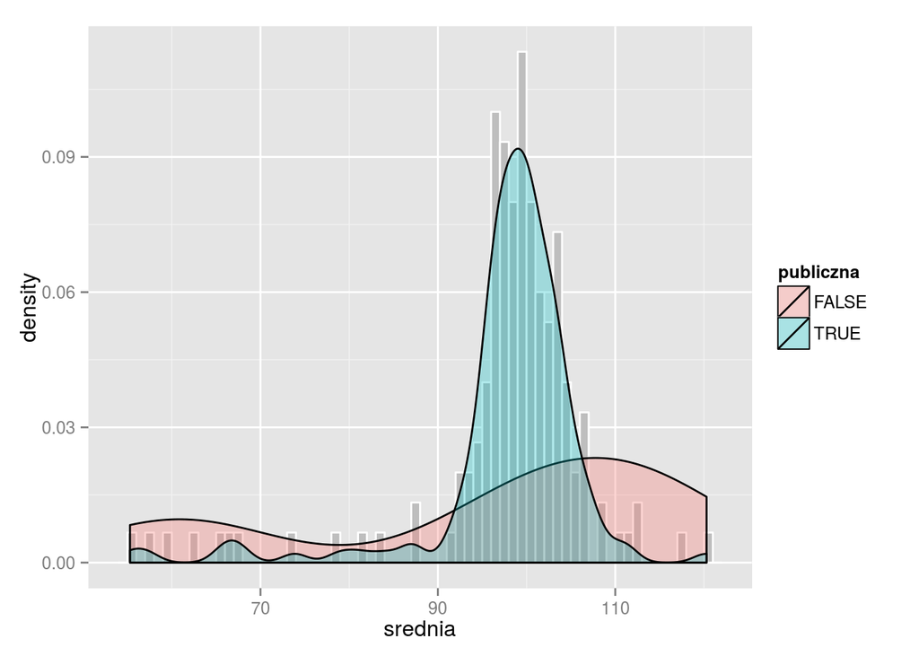

```r
ggplot(pwe_gim_opolskie, aes(x=srednia, fill=publiczna)) +
  geom_histogram(aes(y=..density..), binwidth=1, position="identity", fill="grey", colour="white") +
  geom_density(alpha=.3)
```

### Pobieranie wskaźników EWD

W poniższym przykładzie pobieramy 3-letnie wskaźniki EWD dla okresu 2010-2012 dla Techników w Krakowie, a następnie wyświetlamy pierwszych 20 wierszy pobranych danych:

```r
# wyszukujemy 3-letnie wskaźniki EWD kończące się w 2012 roku
wskazniki_ewd = pobierz_wskazniki(src) %>%
  filter(
    rodzaj_wsk == "ewd",
    okres == 3,
    rok_do == 2012
  )

# wyszukujemy technika w Krakowie
szkoly_ewd = pobierz_szkoly(src) %>%
  filter(
    powiat_szkoly == "Kraków",
    typ_szkoly == 'T'
  )

# pobieramy wartości wskaźników odfiltrowując wyżej pobranymi danymi
ewd_t_krakow = pobierz_wartosci_wskaznikow(src) %>%
  semi_join(wskazniki_ewd) %>%
  inner_join(szkoly_ewd) %>%
  collect()

# podglądamy wybrane zmienne pierwszych 20 wierszy
ewd_t_krakow %>%
  select(wskaznik, srednia, ewd, nazwa_szkoly, publiczna) %>%
  head(20)
```

```
## Source: local data frame [20 x 5]
##
##       wskaznik  srednia       ewd
## 1   mth_tl_wgr  97.3746 -2.903260
## 2   mtp_tl_wgr  97.1553 -2.641380
## 3  mtmp_tl_wgr 100.5520 -1.531770
## 4   mtm_tl_wgr 100.5300 -1.272250
## 5   mth_tl_wgr 104.5010  2.930110
## 6   mtp_tl_wgr 104.2170  3.113370
## 7  mtmp_tl_wgr 104.9380  1.628260
## 8   mtm_tl_wgr 104.8190  1.793460
## 9   mth_tl_wgr 101.4650  1.585750
## 10  mtp_tl_wgr 101.6500  1.487640
## 11 mtmp_tl_wgr  91.7570 -4.443880
## 12  mtm_tl_wgr  91.4975 -4.938350
## 13  mth_tl_wgr  99.3468  1.062060
## 14  mtp_tl_wgr  98.7639  0.593189
## 15 mtmp_tl_wgr  97.3054 -0.531617
## 16  mtm_tl_wgr  97.3216 -0.486562
## 17  mth_tl_wgr  98.3000 -2.013750
## 18  mtp_tl_wgr  98.0457 -2.339020
## 19 mtmp_tl_wgr  94.2879 -4.069730
## 20  mtm_tl_wgr  94.2552 -4.162610
## Variables not shown: nazwa_szkoly (chr), publiczna (lgl)
```